# Introduction to imaginarycss: Analyzing Cognitive Social Structures

George Vega Yon, Sima Najafzadehkhoei

2025-08-04

# Introduction

The `imaginarycss` package provides tools for analyzing **Cognitive Social Structures** (CSS), focusing on the discrepancies between actual social networks and individuals’ perceptions of those networks. This package is particularly useful for understanding how people perceive social relationships and the systematic errors they make in their social cognition.

## What are Cognitive Social Structures?

Cognitive Social Structures (CSS) represent how individuals perceive the entire social network around them, not just their own relationships. Think of it this way: while traditional network analysis asks “Who is connected to whom?”, CSS analysis asks “Who thinks who is connected to whom?”

### The Core Concept

Imagine you work in an office with 10 people. You have your own understanding of who talks to whom, who collaborates with whom, and who are friends. But your perception might be different from reality, and certainly different from what your colleagues perceive. CSS captures these multiple, potentially conflicting views of the same social reality.

### Why This Matters

Understanding perceptual differences in social networks is crucial because:

1. **Decision Making**: People base their social strategies on their perceptions, not reality
2. **Information Flow**: Misperceptions can block or redirect information paths
3. **Organizational Dynamics**: Leadership effectiveness often depends on accurate social perception
4. **Social Psychology**: Systematic biases reveal fundamental cognitive processes

### Types of Perceptual Errors

When we compare perceived networks to actual networks, several types of errors emerge:

- **False Positives**: Seeing connections that don’t exist (“imaginary ties”)
- **False Negatives**: Missing connections that do exist (“invisible ties”)
- **Reciprocity Errors**: Misperceiving whether relationships are mutual
- **Asymmetric Biases**: Systematically over- or under-estimating certain types of relationships

When we compare these perceptions to the actual network structure, we can identify various types of perceptual errors that reveal important insights about social cognition.

## Key Features

- **Network Construction**: Create binary array graphs from matrices or lists of adjacency matrices
- **Error Analysis**: Compute various types of perceptual errors including reciprocity errors and imaginary census
- **Null Models**: Generate null distributions for testing the prevalence of imaginary structures
- **Tie-Level Accuracy**: Analyze individual-level accuracy rates for perceiving ties and non-ties
- **Network Sampling**: Sample perceived networks based on individual accuracy rates

Let’s start by loading the package:

```r
library(imaginarycss)
library(ggplot2)
library(dplyr)
library(viridis)

# Set a beautiful theme for all plots
theme_set(theme_minimal(base_size = 12) +
  theme(
    plot.title = element_text(size = 16, face = "bold", color = "#2c3e50"),
    plot.subtitle = element_text(size = 12, color = "#7f8c8d"),
    axis.title = element_text(size = 11, color = "#34495e"),
    panel.grid.minor = element_blank(),
    panel.grid.major = element_line(color = "#ecf0f1", size = 0.5),
    legend.title = element_text(size = 10, face = "bold"),
    plot.background = element_rect(fill = "#ffffff", color = NA),
    panel.background = element_rect(fill = "#ffffff", color = NA)
  ))

# Define a beautiful color palette
css_colors <- c(
  primary = "#3498db",
  secondary = "#e74c3c",
  accent = "#9b59b6",
  success = "#27ae60",
  warning = "#f39c12",
  info = "#17a2b8",
  light = "#95a5a6",
  dark = "#2c3e50"
)
```

# Basic Usage

## Creating a Barry Graph

The fundamental data structure in `imaginarycss` is the `barry_graph` object, which represents a collection of networks where the first network is the “true” network and subsequent networks represent different individuals’ perceptions.

### Understanding the Data Structure

A `barry_graph` object is essentially a “stack” of adjacency matrices: - **Layer 0**: The actual/true network (ground truth) - **Layer 1**: Person 1’s perception of the entire network - **Layer 2**: Person 2’s perception of the entire network - **Layer N**: Person N’s perception of the entire network

This structure allows us to compare what each person thinks the network looks like against reality and against each other’s perceptions.

### Why “Barry Graph”?

The name comes from the underlying C++ library that efficiently handles binary array operations on multiple network layers simultaneously. This allows for fast computation of complex network comparisons that would be slow with traditional matrix operations.

### Example 1: Simple Network from Matrix

Let’s create a simple example with a 4-node network:

```r
# Define edges for the true network and one perceived network
source_ <- c(1, 2, 3, 1)
target_ <- c(2, 1, 4, 4)

# Add perceived network (shifted by network size)
source_ <- c(source_, source_[-1] + 4)
target_ <- c(target_, target_[-1] + 4)

# Create adjacency matrix
adjmat <- matrix(0L, nrow = 8, ncol = 8)
adjmat[cbind(source_, target_)] <- 1L

# Create barry_graph object
graph <- new_barry_graph(adjmat, n = 4)
print(graph)
```

```
#> A barry_graph with 2 networks of size 4
#> .    .  1.00     .  1.00     .     .     .     .
#>  1.00     .     .     .     .     .     .     .
#>     .     .     .  1.00     .     .     .     .
#>     .     .     .     .     .     .     .     .
#>     .     .     .     .     .     .     .  1.00
#>     .     .     .     .  1.00     .     .     .
#>     .     .     .     .     .     .     .  1.00
#>     .     .     .     .     .     .     .     .
```

**What’s happening here?**

1. **True Network**: We define a 4-person network with edges (1→2, 2→1, 3→4, 1→4)
2. **Perceived Network**: We create one person’s perception by taking some of the true edges and shifting their indices by the network size (4)
3. **Combined Matrix**: The 8×8 matrix contains both networks stacked together
4. **Barry Graph**: The `new_barry_graph()` function recognizes this structure and creates the specialized object

The key insight is that the person’s perception (edges 2→1, 3→4, 1→4 shifted to positions 6→5, 7→8, 5→8) represents what one individual thinks the network looks like - which may differ from reality.

### Example 2: Network from List of Matrices

Alternatively, you can create a barry_graph from a list of adjacency matrices:

```r
# True network (4x4)
true_net <- matrix(c(
  0, 1, 0, 1,
  1, 0, 1, 0,
  0, 1, 0, 1,
  1, 0, 1, 0
), nrow = 4, byrow = TRUE)

# Perceived network by individual 1
perceived_net1 <- matrix(c(
  0, 1, 1, 1,  # Person 1 thinks there are more connections
  1, 0, 1, 0,
  1, 1, 0, 1,
  1, 0, 1, 0
), nrow = 4, byrow = TRUE)

# Perceived network by individual 2
perceived_net2 <- matrix(c(
  0, 1, 0, 0,  # Person 2 thinks there are fewer connections
  1, 0, 0, 0,
  0, 0, 0, 1,
  0, 0, 1, 0
), nrow = 4, byrow = TRUE)

# Create barry_graph from list
net_list <- list(true_net, perceived_net1, perceived_net2)
graph_from_list <- new_barry_graph(net_list)
print(graph_from_list)
```

```
#> A barry_graph with 3 networks of size 4
#> .    .  1.00     .  1.00     .     .     .     .     .     .
#>  1.00     .  1.00     .     .     .     .     .     .     .
#>     .  1.00     .  1.00     .     .     .     .     .     .
#>  1.00     .  1.00     .     .     .     .     .     .     .
#>     .     .     .     .     .  1.00  1.00  1.00     .     .
#>     .     .     .     .  1.00     .  1.00     .     .     .
#>     .     .     .     .  1.00  1.00     .  1.00     .     .
#>     .     .     .     .  1.00     .  1.00     .     .     .
#>     .     .     .     .     .     .     .     .     .  1.00
#>     .     .     .     .     .     .     .     .  1.00     .
#> Skipping 2 rows. Skipping 2 columns.
```

**Understanding the Perceptual Differences:**

These different perceptions could arise from various factors: - **Position in network**: Central people might see more connections - **Personality traits**: Extroverts might perceive more social activity - **Attention patterns**: Some people notice strong ties, others notice weak signals - **Social desirability**: People might report what they think should exist

## Key Attributes

Every `barry_graph` object has important attributes:

```r
# Network size (number of nodes)
cat("Network size:", attr(graph, "netsize"), "\n")
```

```
#> Network size: 4
```

```r
# Endpoints (boundaries between networks in the combined structure)
cat("Endpoints:", attr(graph, "endpoints"), "\n")
```

```
#> Endpoints: 8
```

```r
# Convert to edgelist for inspection
edgelist <- barray_to_edgelist(graph)
head(edgelist)
```

```
#>      source target
#> [1,]      1      2
#> [2,]      1      4
#> [3,]      2      1
#> [4,]      3      4
#> [5,]      5      8
#> [6,]      6      5
```

# Analyzing Perceptual Errors

Understanding how and why people misperceive social networks is at the heart of CSS analysis. The `imaginarycss` package provides several sophisticated measures to quantify different types of perceptual errors.

## Reciprocity Errors

Reciprocity - whether relationships are mutual - is a fundamental property of social networks. When person A says they’re friends with person B, is the feeling mutual? Reciprocity errors occur when individuals misperceive the reciprocal nature of relationships.

### Types of Reciprocity Errors

1. **Assumed Reciprocity**: Thinking a one-way relationship is mutual
2. **Missed Reciprocity**: Thinking a mutual relationship is one-way
3. **False Asymmetry**: Seeing asymmetry where there’s actually reciprocity
4. **False Symmetry**: Seeing reciprocity where there’s actually asymmetry

### Why Reciprocity Matters

- **Social Expectations**: We expect important relationships to be reciprocal
- **Cognitive Load**: It’s easier to remember “A and B are friends” than “A likes B but B doesn’t like A”
- **Projection**: We assume others feel the same way about us as we do about them

```r
# Compute reciprocity errors
recip_errors <- count_recip_errors(graph)
print(recip_errors)
```

```
#>    id                                    name value
#> 1   0    Partially false recip (omission) (0)     1
#> 2   0   Partially false recip (comission) (0)     0
#> 3   0   Completely false recip (omission) (0)     0
#> 4   0  Completely false recip (comission) (0)     0
#> 5   0            Mixed reciprocity errors (0)     0
#> 6   0                  (01) Accurate null (0)     3
#> 7   0  (02) Partial false positive (null) (0)     0
#> 8   0 (03) Complete false positive (null) (0)     0
#> 9   0 (04) Partial false negative (assym) (0)     0
#> 10  0                 (05) Accurate assym (0)     2
#> 11  0                    (06) Mixed assym (0)     0
#> 12  0 (07) Partial false positive (assym) (0)     0
#> 13  0 (08) Complete false negative (full) (0)     0
#> 14  0  (09) Partial false negative (full) (0)     1
#> 15  0                  (10) Accurate full (0)     0
```

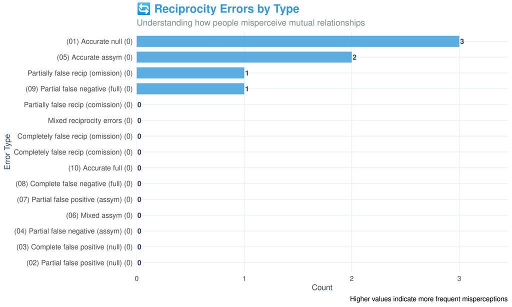

```r
# Visualize the distribution
ggplot(recip_errors, aes(x = reorder(name, value), y = value)) +
  geom_col(
    fill = css_colors["primary"],
    alpha = 0.8,
    width = 0.7
  ) +
  geom_text(
    aes(label = value),
    hjust = -0.2,
    color = css_colors["dark"],
    size = 3.5,
    fontface = "bold"
  ) +
  coord_flip() +
  scale_y_continuous(expand = expansion(mult = c(0, 0.15))) +
  labs(
    title = "🔄 Reciprocity Errors by Type",
    subtitle = "Understanding how people misperceive mutual relationships",
    x = "Error Type",
    y = "Count",
    caption = "Higher values indicate more frequent misperceptions"
  ) +
  theme(
    axis.text.y = element_text(size = 10),
    plot.title = element_text(color = css_colors["primary"])
  )
```

## Imaginary Census

The imaginary census provides a comprehensive classification of all possible perceptual errors. Think of it as a “taxonomy of mistakes” - every possible way someone can misperceive a dyadic relationship gets its own category.

### The 10 Categories Explained

The census classifies every dyad (pair of people) based on: 1. **What actually exists** (null, asymmetric, or reciprocal tie) 2. **What the perceiver thinks exists** (null, asymmetric, or reciprocal tie)

This creates a 3×3 matrix of possibilities, but some combinations are subdivided:

#### **Null Dyads** (no actual connection):

- **(01) Accurate Null**: Correctly perceives no connection
- **(02) Partial False Positive**: Sees one-way connection where none exists
- **(03) Complete False Positive**: Sees mutual connection where none exists

#### **Asymmetric Dyads** (one-way connection):

- **(04) Partial False Negative**: Misses the connection entirely
- **(05) Accurate Asymmetric**: Correctly sees one-way connection
- **(06) Mixed Asymmetric**: Sees connection but gets direction wrong
- **(07) Partial False Positive**: Sees mutual connection where only one-way exists

#### **Reciprocal Dyads** (mutual connection):

- **(08) Complete False Negative**: Misses the connection entirely
- **(09) Partial False Negative**: Sees only one direction of mutual tie
- **(10) Accurate Reciprocal**: Correctly perceives mutual connection

### Cognitive Implications

Different error patterns suggest different underlying cognitive processes: - **High false positives**: “Rose-colored glasses” - seeing connections everywhere - **High false negatives**: “Tunnel vision” - missing connections that exist  
- **Direction errors**: Difficulty with asymmetric relationships - **Reciprocity bias**: Tendency to assume relationships are mutual

```r
# Compute full imaginary census
census <- count_imaginary_census(graph)
print(census)
```

```
#>    id                                    name value
#> 1   0                  (01) Accurate null (0)     3
#> 2   0  (02) Partial false positive (null) (0)     0
#> 3   0 (03) Complete false positive (null) (0)     0
#> 4   0 (04) Partial false negative (assym) (0)     0
#> 5   0                 (05) Accurate assym (0)     2
#> 6   0                    (06) Mixed assym (0)     0
#> 7   0 (07) Partial false positive (assym) (0)     0
#> 8   0 (08) Complete false negative (full) (0)     0
#> 9   0  (09) Partial false negative (full) (0)     1
#> 10  0                  (10) Accurate full (0)     0
```

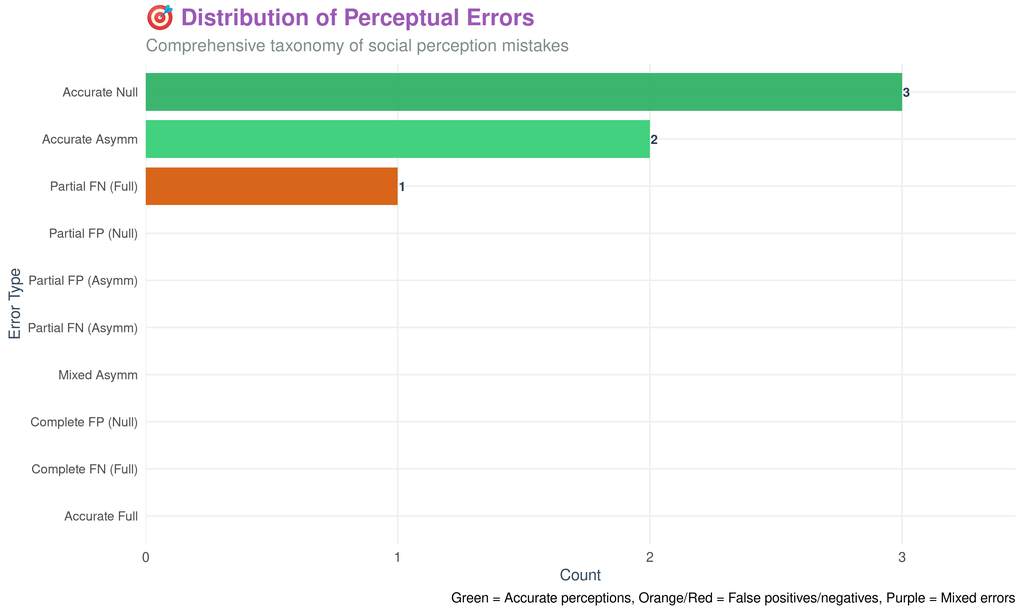

```r
# Clean up names for better visualization
# Convert to regular data frame to avoid class conflicts
census_df <- census[, names(census)]  # Strip custom class
class(census_df) <- "data.frame"

census_df$name_clean <- gsub("\\([0-9]+\\)$", "", census_df$name)
census_summary <- census_df %>%
  filter(grepl("^\\([0-9]", name)) %>%
  mutate(
    error_type = case_when(
      grepl("Accurate null", name_clean) ~ "Accurate Null",
      grepl("Partial false positive \\(null\\)", name_clean) ~ "Partial FP (Null)",
      grepl("Complete false positive \\(null\\)", name_clean) ~ "Complete FP (Null)",
      grepl("Partial false negative \\(assym\\)", name_clean) ~ "Partial FN (Asymm)",
      grepl("Accurate assym", name_clean) ~ "Accurate Asymm",
      grepl("Mixed assym", name_clean) ~ "Mixed Asymm",
      grepl("Partial false positive \\(assym\\)", name_clean) ~ "Partial FP (Asymm)",
      grepl("Complete false negative \\(full\\)", name_clean) ~ "Complete FN (Full)",
      grepl("Partial false negative \\(full\\)", name_clean) ~ "Partial FN (Full)",
      grepl("Accurate full", name_clean) ~ "Accurate Full",
      TRUE ~ "Other"
    )
  )

# Create a beautiful color palette for error types
error_colors <- c(
  "Accurate Null" = "#27ae60",           # Green for accurate
  "Accurate Asymm" = "#2ecc71",          # Light green
  "Accurate Full" = "#16a085",           # Teal
  "Partial FP (Null)" = "#f39c12",       # Orange for mild errors
  "Partial FN (Asymm)" = "#e67e22",      # Dark orange
  "Partial FN (Full)" = "#d35400",       # Red-orange
  "Complete FP (Null)" = "#e74c3c",      # Red for serious errors
  "Complete FN (Full)" = "#c0392b",      # Dark red
  "Partial FP (Asymm)" = "#8e44ad",      # Purple
  "Mixed Asymm" = "#9b59b6",             # Light purple
  "Other" = "#95a5a6"                    # Gray for other
)

# Visualize error distribution
ggplot(census_summary, aes(x = reorder(error_type, value), y = value)) +
  geom_col(aes(fill = error_type), alpha = 0.9, width = 0.8) +
  geom_text(
    aes(label = ifelse(value > 0, value, "")),
    hjust = -0.1,
    color = "#2c3e50",
    size = 3.2,
    fontface = "bold"
  ) +
  scale_fill_manual(values = error_colors) +
  coord_flip() +
  scale_y_continuous(expand = expansion(mult = c(0, 0.15))) +
  labs(
    title = "🎯 Distribution of Perceptual Errors",
    subtitle = "Comprehensive taxonomy of social perception mistakes",
    x = "Error Type",
    y = "Count",
    caption = "Green = Accurate perceptions, Orange/Red = False positives/negatives, Purple = Mixed errors"
  ) +
  guides(fill = "none") +
  theme(
    axis.text.y = element_text(size = 9),
    plot.title = element_text(color = css_colors["accent"])
  )
```

# Analyzing Individual Accuracy

Individual differences in social perception are often more interesting than aggregate patterns. Some people are “social radar” - exceptionally good at reading social networks. Others are “social blind spots” - systematically missing important patterns.

## Tie-Level Accuracy

This analysis breaks down accuracy into four key measures, distinguishing between different types of relationships and different types of correct judgments.

### The Four Accuracy Measures

1. **True Positive (Ego)**: Correctly identifying ties that involve the perceiver
   - “I correctly know who I’m connected to”
   - High scores suggest good self-awareness
2. **True Negative (Ego)**: Correctly identifying non-ties that involve the perceiver
   - “I correctly know who I’m NOT connected to”
   - High scores suggest realistic self-assessment
3. **True Positive (Alter)**: Correctly identifying ties between other people
   - “I correctly know who else is connected”
   - High scores suggest good social observation skills
4. **True Negative (Alter)**: Correctly identifying non-ties between other people
   - “I correctly know who else is NOT connected”
   - High scores suggest avoiding false gossip/assumptions

### Why This Decomposition Matters

**Ego vs. Alter Accuracy:** - People are typically more accurate about their own relationships (ego) than others’ relationships (alter) - But some individuals are better “social observers” and excel at alter accuracy - The ratio can reveal whether someone is self-focused vs. socially aware

**True Positive vs. True Negative Accuracy:** - True positive accuracy: “Am I good at spotting connections?” - True negative accuracy: “Am I good at recognizing when there’s no connection?” - Different cognitive processes may underlie these two abilities

Understanding individual differences in perception accuracy is crucial:

```r
# Compute tie-level accuracy for each individual
accuracy <- tie_level_accuracy(graph)
print(accuracy)
```

```
#>   k p_0_ego   p_1_ego p_0_alter p_1_alter
#> 1 1       1 0.3333333         1         0
```

[figure not shown]

```r
# Reshape data for visualization
# Convert to regular data frame first to avoid class conflicts
accuracy_df <- accuracy[, names(accuracy)]  # Strip custom class
class(accuracy_df) <- "data.frame"

accuracy_long <- accuracy_df %>%
  select(-k) %>%
  tidyr::pivot_longer(
    everything(),
    names_to = "measure",
    values_to = "probability"
  ) %>%
  mutate(
    measure_clean = case_when(
      measure == "p_0_ego" ~ "True Negative (Ego)",
      measure == "p_1_ego" ~ "True Positive (Ego)",
      measure == "p_0_alter" ~ "True Negative (Alter)",
      measure == "p_1_alter" ~ "True Positive (Alter)"
    )
  )

# Create color palette for accuracy measures
accuracy_colors <- c(
  "True Negative (Ego)" = "#3498db",     # Blue
  "True Positive (Ego)" = "#2980b9",     # Dark blue
  "True Negative (Alter)" = "#e74c3c",   # Red
  "True Positive (Alter)" = "#c0392b"    # Dark red
)

# Visualize accuracy measures
p1 <- ggplot(accuracy_long, aes(x = measure_clean, y = probability)) +
  geom_violin(
    aes(fill = measure_clean),
    alpha = 0.7,
    trim = FALSE,
    scale = "width"
  ) +
  geom_boxplot(
    width = 0.2,
    alpha = 0.8,
    outlier.alpha = 0.6,
    outlier.size = 1.5
  ) +
  geom_jitter(
    width = 0.15,
    alpha = 0.6,
    size = 2,
    color = "#2c3e50"
  ) +
  scale_fill_manual(values = accuracy_colors) +
  scale_y_continuous(labels = scales::percent_format()) +
  labs(
    title = "🎯 Individual-Level Accuracy Rates",
    subtitle = "How well do people perceive different types of relationships?",
    x = "Accuracy Measure",
    y = "Accuracy Rate (%)",
    caption = "Blue = Ego relationships (involving self), Red = Alter relationships (between others)"
  ) +
  guides(fill = "none") +
  theme(
    axis.text.x = element_text(angle = 30, hjust = 1, size = 10),
    plot.title = element_text(color = css_colors["info"]),
    panel.grid.major.x = element_blank()
  )

print(p1)
```

# Generating Null Models

Statistical testing in network analysis requires careful null models. We can’t just use random networks because individual perceptual biases aren’t random - they’re systematic and person-specific.

## The Challenge of Network Null Models

Traditional approaches might use: - **Random networks**: But real perception isn’t random - **Erdős-Rényi models**: But they ignore individual differences - **Configuration models**: But they don’t capture perceptual biases

### Our Solution: Accuracy-Based Sampling

The `imaginarycss` approach uses individual accuracy rates to generate realistic null distributions:

1. **Measure each person’s accuracy** for different types of relationships
2. **Use these rates as probabilities** for generating simulated perceptions
3. **Preserve individual differences** while randomizing specific errors
4. **Generate many samples** to build null distributions

This approach asks: “If someone has X% accuracy rate for ego ties and Y% accuracy for alter ties, what range of error patterns would we expect by chance?”

## Sampling Perceived Networks

The sampling process works as follows:

1. **Start with the true network** as baseline
2. **For each perceiver and each potential tie:**
   - If it’s an ego tie: Use their ego accuracy rate
   - If it’s an alter tie: Use their alter accuracy rate
   - If it should exist: Use true positive rate as probability
   - If it shouldn’t exist: Use true negative rate as probability
3. **Generate binary outcome** based on these probabilities
4. **Repeat many times** to create distribution

```r
# Sample a single network based on accuracy rates
set.seed(123)
sampled_networks <- sample_css_network(graph, keep_baseline = TRUE)

cat("Number of sampled networks:", length(sampled_networks), "\n")
```

```
#> Number of sampled networks: 2
```

```r
cat("Dimensions of each network:", dim(sampled_networks[[1]]), "\n")
```

```
#> Dimensions of each network: 4 4
```

```r
# Compare original vs sampled network density
original_density <- sum(sampled_networks[[1]]) / (4 * 3)  # exclude diagonal
sampled_density <- sum(sampled_networks[[2]]) / (4 * 3)

cat("Original network density:", round(original_density, 3), "\n")
```

```
#> Original network density: 0.333
```

```r
cat("Sampled network density:", round(sampled_density, 3), "\n")
```

```
#> Sampled network density: 0
```

## Generating Multiple Samples for Statistical Testing

The power of null models comes from generating many samples to understand the distribution of outcomes we’d expect by chance alone.

### The Statistical Logic

1. **Observed Pattern**: We see X false positives in our data
2. **Null Hypothesis**: This is just what we’d expect given individual accuracy rates
3. **Null Distribution**: Generate 1000+ samples using accuracy rates as probabilities
4. **P-value**: What proportion of null samples have ≥ X false positives?
5. **Interpretation**: If p < 0.05, the observed pattern is unlikely due to chance

### Why This Approach Works

- **Preserves individual differences**: Each person’s bias level stays realistic
- **Controls for network density**: Null models have similar overall connection rates
- **Accounts for position effects**: Ego vs. alter accuracy differences are maintained
- **Enables fair comparison**: Only the specific pattern of errors is randomized

```r
# Generate multiple samples for null distribution
set.seed(456)
n_samples <- 100

# Note: For this example, we'll use a simpler approach
# since the full null sampling may require additional setup
null_samples <- replicate(n_samples, {
  sample_css_network(graph, keep_baseline = FALSE)
}, simplify = FALSE)

# For demonstration, let's compute a simple metric instead of full census
# We'll count the total number of ties in each sampled network
null_densities <- sapply(null_samples, function(nets) {
  if (length(nets) > 0) {
    sum(nets[[1]]) / (4 * 3)  # Network density
  } else {
    0
  }
})

# Compare with observed density
observed_density <- sum(sampled_networks[[2]]) / (4 * 3)

# Calculate p-value first
p_value <- mean(null_densities >= observed_density)
cat("P-value for network density:", round(p_value, 4), "\n")
```

```
#> P-value for network density: 1
```

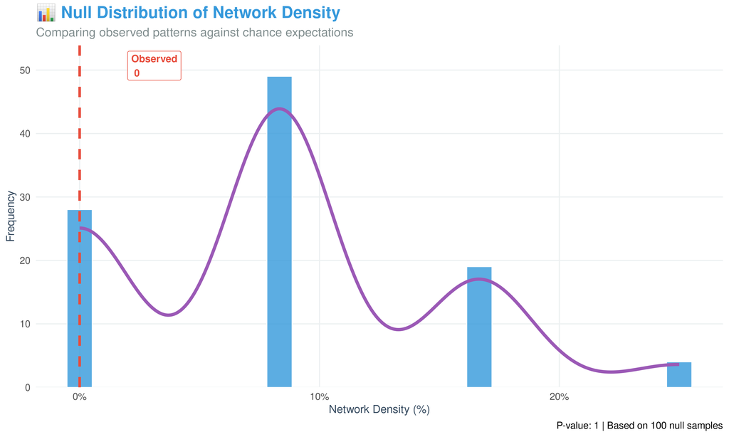

```r
# Visualization
null_df <- data.frame(
  density = null_densities,
  type = "Null Distribution"
)

# Create beautiful density comparison plot
density_plot <- ggplot(null_df, aes(x = density)) +
  geom_histogram(
    bins = 25,
    alpha = 0.8,
    fill = css_colors["primary"],
    color = "white",
    size = 0.3
  ) +
  geom_vline(
    xintercept = observed_density,
    color = css_colors["secondary"],
    linetype = "dashed",
    size = 1.2
  ) +
  geom_density(
    aes(y = after_stat(density) * length(null_densities) * 0.05),
    color = css_colors["accent"],
    size = 1.5,
    alpha = 0.7
  ) +
  annotate(
    "label",
    x = observed_density + 0.02,
    y = Inf,
    label = paste("Observed\n", round(observed_density, 3)),
    vjust = 1.2,
    hjust = 0,
    color = css_colors["secondary"],
    fill = "white",
    size = 3.5,
    fontface = "bold",
    label.padding = unit(0.3, "lines")
  ) +
  scale_x_continuous(labels = scales::percent_format()) +
  scale_y_continuous(expand = expansion(mult = c(0, 0.1))) +
  labs(
    title = "📊 Null Distribution of Network Density",
    subtitle = "Comparing observed patterns against chance expectations",
    x = "Network Density (%)",
    y = "Frequency",
    caption = paste("P-value:", round(p_value, 4), "| Based on", n_samples, "null samples")
  ) +
  theme(
    plot.title = element_text(color = css_colors["primary"]),
    panel.grid.major.x = element_line(color = "#ecf0f1", size = 0.5),
    panel.grid.major.y = element_line(color = "#ecf0f1", size = 0.5)
  )

print(density_plot)
```

# Advanced Analysis: Counter Types

One of the most sophisticated features of `imaginarycss` is the ability to decompose errors based on the perceiver’s involvement in the relationship being judged.

## The Psychology Behind Ego vs. Alter Perception

### Why This Distinction Matters

**Ego-Involved Relationships** (perceiver is part of the dyad): - **Higher stakes**: These relationships directly affect the perceiver - **More information**: Direct experience vs. observation - **Different biases**: Self-enhancement, wishful thinking, social desirability - **Example**: Person A judging whether A↔︎B connection exists

**Alter-Alter Relationships** (perceiver observes others): - **Lower stakes**: These relationships don’t directly involve the perceiver  
- **Less information**: Must rely on observation and inference - **Different biases**: Stereotyping, availability heuristic, gossip effects - **Example**: Person A judging whether B↔︎C connection exists

### Theoretical Predictions

Research suggests several patterns:

1. **Ego Accuracy Advantage**: People should be more accurate about their own relationships
2. **Ego Positivity Bias**: People might over-report their own connections (social desirability)
3. **Alter Projection**: People might assume others have relationships similar to their own
4. **Alter Visibility**: Some alter relationships are more visible/observable than others

## Separating Ego vs. Alter Perceptions

The package allows you to analyze errors separately based on whether the perceiver is involved in the relationship:

```r
# All ties
census_all <- count_imaginary_census(graph, counter_type = 0)

# Only ties involving the perceiver (ego)
census_ego <- count_imaginary_census(graph, counter_type = 1)

# Only ties not involving the perceiver (alter-alter)
census_alter <- count_imaginary_census(graph, counter_type = 2)

# Verify that ego + alter = all
verification <- census_all$value - (census_ego$value + census_alter$value)
all_match <- all(verification == 0)
cat("Ego + Alter counts equal All counts:", all_match, "\n")
```

```
#> Ego + Alter counts equal All counts: TRUE
```

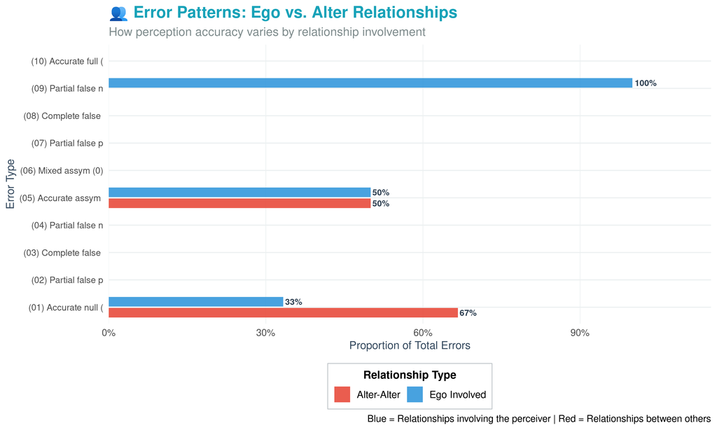

```r
# Compare error patterns
# Convert to regular data frame to avoid class conflicts
census_all_df <- census_all[, names(census_all)]
class(census_all_df) <- "data.frame"
census_ego_df <- census_ego[, names(census_ego)]
class(census_ego_df) <- "data.frame"
census_alter_df <- census_alter[, names(census_alter)]
class(census_alter_df) <- "data.frame"

compare_df <- data.frame(
  error_type = census_all_df$name,
  all_ties = census_all_df$value,
  ego_ties = census_ego_df$value,
  alter_ties = census_alter_df$value
) %>%
  filter(grepl("^\\([0-9]", error_type)) %>%
  mutate(
    ego_proportion = ego_ties / all_ties,
    alter_proportion = alter_ties / all_ties
  )

# Visualize the comparison
compare_long <- compare_df %>%
  select(error_type, ego_proportion, alter_proportion) %>%
  tidyr::pivot_longer(
    cols = c(ego_proportion, alter_proportion),
    names_to = "tie_type",
    values_to = "proportion"
  ) %>%
  mutate(
    tie_type = ifelse(tie_type == "ego_proportion", "Ego Involved", "Alter-Alter"),
    error_short = substr(error_type, 1, 20)
  )

# Create gradient colors for ego vs alter comparison
relationship_colors <- c(
  "Ego Involved" = "#3498db",
  "Alter-Alter" = "#e74c3c"
)

# Create a more sophisticated comparison plot
comparison_plot <- ggplot(compare_long, aes(x = error_short, y = proportion, fill = tie_type)) +
  geom_col(
    position = position_dodge(width = 0.8),
    alpha = 0.9,
    width = 0.7
  ) +
  geom_text(
    aes(label = ifelse(proportion > 0.02, scales::percent(proportion, accuracy = 1), "")),
    position = position_dodge(width = 0.8),
    hjust = -0.1,
    size = 3,
    fontface = "bold",
    color = "#2c3e50"
  ) +
  scale_fill_manual(
    values = relationship_colors,
    name = "Relationship Type"
  ) +
  scale_y_continuous(
    labels = scales::percent_format(),
    expand = expansion(mult = c(0, 0.15))
  ) +
  coord_flip() +
  labs(
    title = "👥 Error Patterns: Ego vs. Alter Relationships",
    subtitle = "How perception accuracy varies by relationship involvement",
    x = "Error Type",
    y = "Proportion of Total Errors",
    caption = "Blue = Relationships involving the perceiver | Red = Relationships between others"
  ) +
  theme(
    legend.position = "bottom",
    legend.title = element_text(size = 11, face = "bold"),
    legend.text = element_text(size = 10),
    axis.text.y = element_text(size = 9),
    plot.title = element_text(color = css_colors["info"]),
    panel.grid.major.x = element_line(color = "#ecf0f1", size = 0.3),
    legend.box.background = element_rect(color = "#bdc3c7", fill = "#ffffff")
  ) +
  guides(
    fill = guide_legend(
      title.position = "top",
      title.hjust = 0.5,
      nrow = 1
    )
  )

print(comparison_plot)
```